# Dealing with missing data in R

Masterclass European Women in Technology

Rianne Schouten

29 november 2018

## Preparation

Go to https://github.com/RianneSchouten/workshops/tree/master/WomenInTechnology to find the google drive link and download the folder to your computer. Then choose

#### Option 1 Open the .html file and **read** along.

#### Option 2 Open the .R file and **work** along.

## Download instructions for R and RStudio

To actively participate in the masterclass, you need R and RStudio. These open source software packages can be downloaded. Information about installation is available [here](https://courses.edx.org/courses/UTAustinX/UT.7.01x/3T2014/56c5437b88fa43cf828bff5371c6a924/). For R, you go to https://www.r-project.org/. For RStudio, you go to https://www.rstudio.com/.

All files can be found in the [google drive](https://drive.google.com/open?id=1zvLt0gnAR7Zg2CZ_pPbeC7BEdmPMVzsH) or in github repository: https://github.com/RianneSchouten/workshops/tree/master/WomenInTechnology. To download the files from the repository, go to https://minhaskamal.github.io/DownGit/#/home and paste the link of the repository. Then click the button ‘Download’.

The folder contains the dataset, some image and 3 other files:

1. The .html file contains everything we will discuss during the masterclass. It shows the explanation, the R code and the output of the R code. You can also use it as a reference for later use.
2. The .Rmd file is the markdown code for the .html file. You can open this file in RStudio and change it to your likings. Click on the ‘Knit’ button to run the file and overwrite the .html file. When you do this the first time, it will ask for the installation of some packages.
3. The R code is also saved in an .R file. Open this file with RStudio and run lines by pressing CTRL + ENTER.

We start by opening the .R file and running the following lines to install two necessary packages. Installation of packages is a one-time event.

```r
install.packages("mice")
install.packages("ggplot2")
```

Then, you load the packages in the current R session by using `library`.

```r
library(mice, warn.conflicts = FALSE, quietly = TRUE)
library(ggplot2, warn.conflicts = FALSE, quietly = TRUE)
```

Now, we are good to go!

## Introduction

**My name is**

Rianne Schouten, 27 years old and I love kickboxing, research and Indian food.

**As missing data methodologist, I**

1. Choose my dataset and define the truth
2. Ampute the data
3. Apply missing data method
4. Analyze the imputed data and compare with the truth

In this workshop we will work through the same four steps. We take some extra time for step 2, to understand missingness mechanisms. Step 3 and 4 will be interwoven.

A simulation normally contains many repetitions to account for sampling error. We will run the procedure only once. To make sure all of us have the same output, we set a seed.

## 1. Dataset

A simulation always starts with a complete dataset. This can be a simulated dataset or a real dataset. One way to simulate a dataset is by using the package `MASS`. I often use the function `mvrnorm` which samples from a multivariate normal distribution.

Today we will use a dataset from Kaggle: [Red Wine Quality](https://www.kaggle.com/uciml/red-wine-quality-cortez-et-al-2009/data).

```r
data <- read.csv("red_wine_quality.txt", sep = '\t')
data <- data[, c('alcohol', 'density', 'pH')]
```

Let’s start by inspecting the data a little bit.

```r
nrow(data)
```

```
## [1] 1599
```

```r
summary(data)
```

```
##     alcohol         density             pH
##  Min.   : 8.40   Min.   :0.9901   Min.   :2.740
##  1st Qu.: 9.50   1st Qu.:0.9956   1st Qu.:3.210
##  Median :10.20   Median :0.9968   Median :3.310
##  Mean   :10.42   Mean   :0.9967   Mean   :3.311
##  3rd Qu.:11.10   3rd Qu.:0.9978   3rd Qu.:3.400
##  Max.   :14.90   Max.   :1.0037   Max.   :4.010
```

```r
cor(data)
```

```
##            alcohol    density         pH
## alcohol  1.0000000 -0.4961798  0.2056325
## density -0.4961798  1.0000000 -0.3416993
## pH       0.2056325 -0.3416993  1.0000000
```

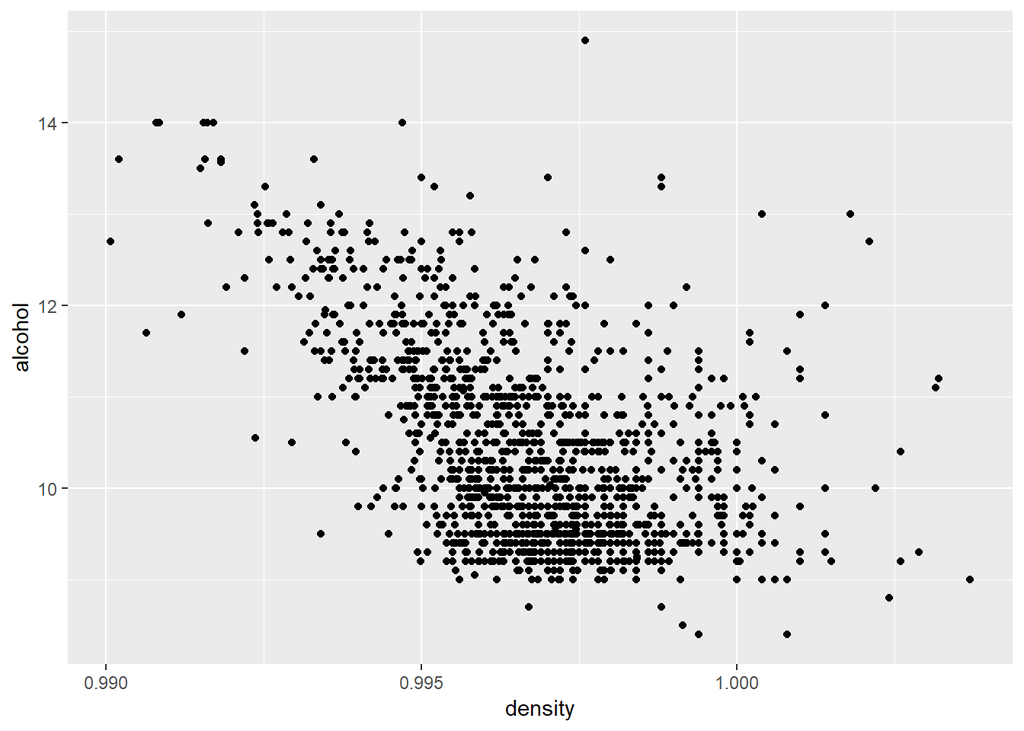

```r
plotdata <- data
ggplot(plotdata, aes(density, alcohol)) +
  geom_point()
```

Today, we will evaluate the beta coefficient of a linear regression model where we regress `alcohol` on `density`. Let’s assume we are able to measure the density of the wine, and based on that measure we want to estimate how much alcohol is in the wine.

```r
truemodel <- glm(alcohol ~ density, family = 'gaussian', data)
true_coefs <- summary(truemodel)$coefficients
true_coefs
```

```
##              Estimate Std. Error   t value      Pr(>|t|)
## (Intercept)  289.6753   12.22745  23.69058 1.417989e-106
## density     -280.1638   12.26734 -22.83820 3.938835e-100
```

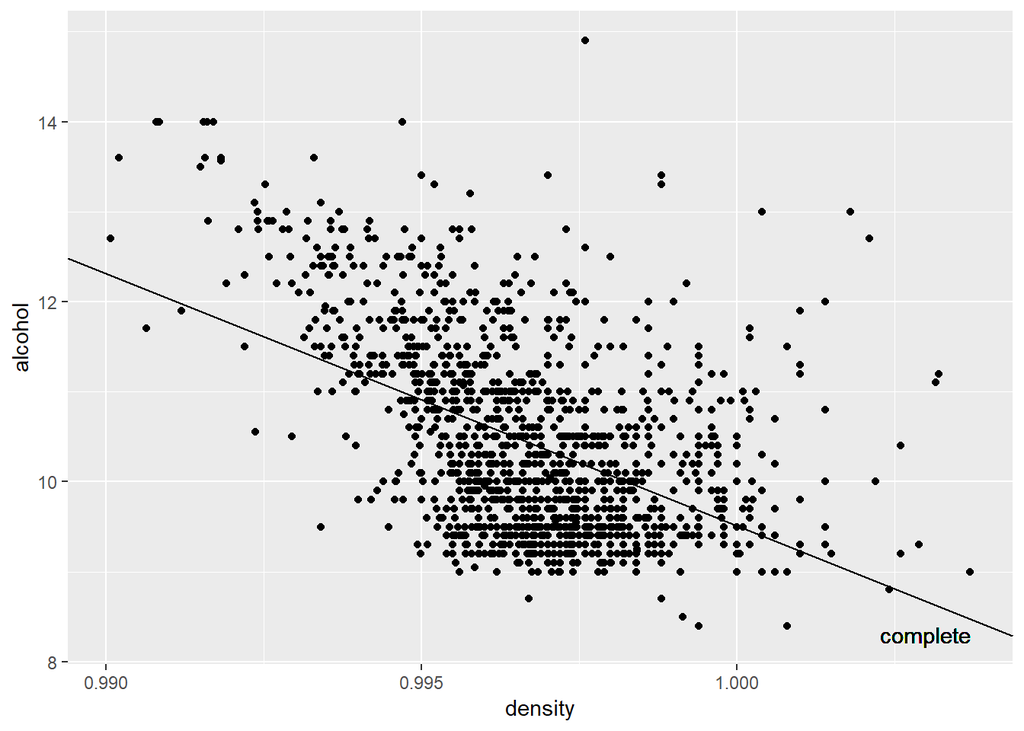

```r
ggplot(plotdata, aes(density, alcohol)) +
  geom_point() +
  geom_abline(slope = true_coefs[2, 1],
              intercept = true_coefs[1, 1],
              color = 'black') +
  geom_text(aes(x = 1.003, y = 8.3),
            label = 'complete', color = 'black')
```

In particular, we are interested in the beta coefficient of `density` and as we have seen, this value is -280.1638231 with a standard error of 12.2673352.

We define these values to be the truth and will now continue with our simulation.

## 2. Amputation

The generation of missing values is called *amputation*. The goal of the amputation procedure is always to generate sophisticated, realistic missingness. In other words, it should represent the real world situation as best as possible.

We will discuss two important aspects of amputation:

1. Generating missingness in multiple variables.
2. Influence the cause/origin/reason for the missingness.

We developed a multivariate amputation procedure and implemented this procedure in R-function `ampute` in package **mice**.

```r
?ampute
mads <- ampute(data,
               prop = 0.5,
               patterns = NULL,
               freq = NULL,
               mech = "MAR",
               weights = NULL,
               cont = TRUE,
               type = NULL,
               odds = NULL,
               bycases = TRUE,
               run = TRUE)
```

Explanation of the underlying method, as well as a demonstration of why this method works better than traditional methods, is given in the research article [Generating missing values for simulation purposes: A multivariate amputation procedure](https://www.tandfonline.com/doi/full/10.1080/00949655.2018.1491577). Explanation of all the arguments of `ampute` can be found in a vignette https://rianneschouten.github.io/mice_ampute/vignette/ampute.html. Today, we will focus on two arguments: `patterns` and `mech`.

First, we run the function with the default options. The output of `ampute` is always a `mads` object, and contains all the arguments used in the amputation procedure. We ask for the `pattern` object by `mads$patterns`.

```r
mads <- ampute(data)
mads$patterns
```

```
##   alcohol density pH
## 1       0       1  1
## 2       1       0  1
## 3       1       1  0
```

The amputed data is stored in `mads$amp`. Because we cannot inspect every row in the dataset, we use function `md.pattern` to get a summary of all missing data patterns. Here, it shows that there are three missing data patterns. In each pattern, there is missingness in one variable. Furthermore, apprximately half of the rows are incomplete. This corresponds to the default settings of `ampute`.

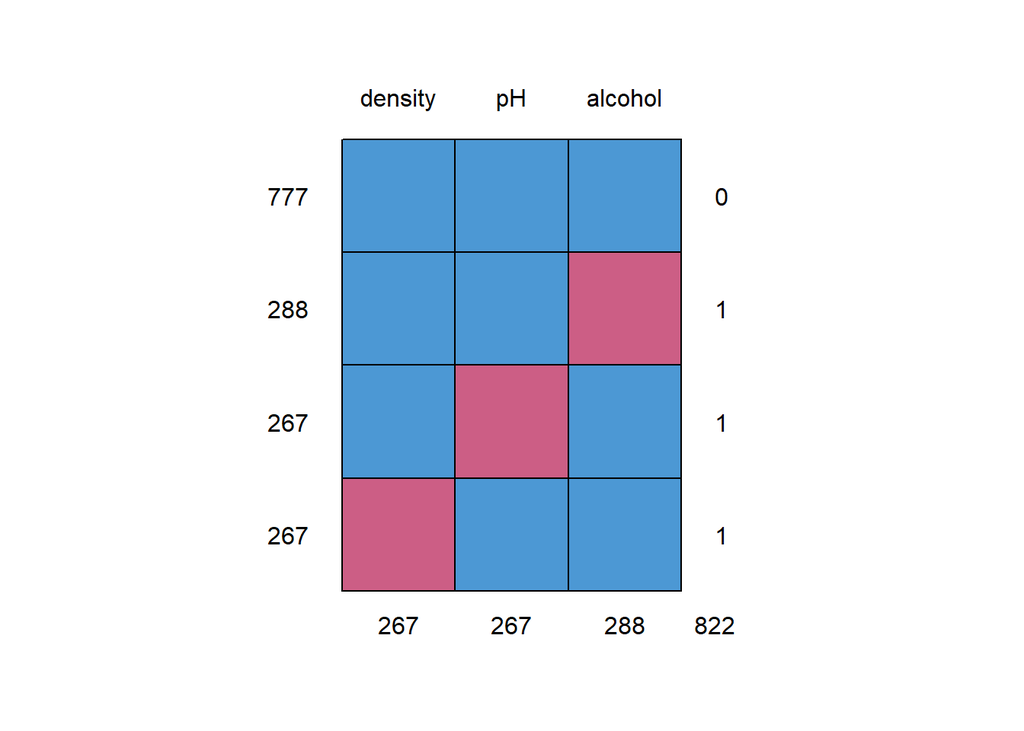

```
##     density  pH alcohol
## 777       1   1       1   0
## 288       1   1       0   1
## 267       1   0       1   1
## 267       0   1       1   1
##         267 267     288 822
```

```r
md.pattern(mads$amp)
```

To influence where the missingness is created, you modify the `patterns` argument. This argument is always a matrix or dataframe where the number of columns equals the number of columns in the data. Each row in the `patterns` matrix is a missing data pattern, and we use `0` for the variables that become incomplete and `1` for the complete variables.

##### If we want to create two patterns in our dataset, where one pattern has missingness in `density` and the other pattern has missingness in both `density` and `pH`, what would the `patterns` object look like?

```r
mypatterns <- matrix(c(1, 0, 1,
                       1, 0, 0),
                     nrow = 2, byrow = TRUE)
mypatterns
```

```
##      [,1] [,2] [,3]
## [1,]    1    0    1
## [2,]    1    0    0
```

Let’s try it.

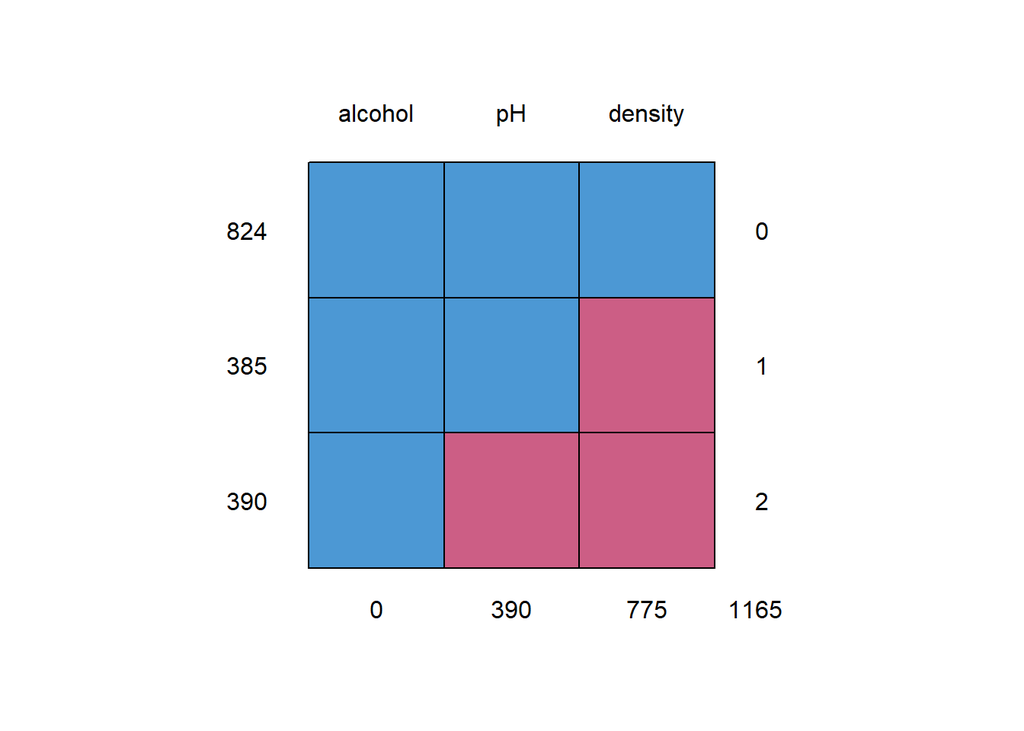

```
##     alcohol  pH density
## 824       1   1       1    0
## 385       1   1       0    1
## 390       1   0       0    2
##           0 390     775 1165
```

```r
mads <- ampute(data = data,
               patterns = mypatterns)
inc_data <- mads$amp
md.pattern(inc_data)
```

The proportion of incomplete rows, and the spreading of the patterns over the incomplete rows can be manipulated with the arguments `prop` and `freq`.

##### What are possible causes/origins/reasons for missingness?

In missing data theory, we divide missingness into three categories:

###### 1. Missing Completely At Random (MCAR):

Missingness is not related to any variable. The probability to be missing is fixed. For instance: Pr(`density` = missing) = 0.5

###### 2. Missing At Random (MAR):

Missingness is related to one or more observed variables. Then, Pr(`density` = missing) = `pH` or Pr(`density` = missing) = `alcohol` or Pr(`density` = missing) = a combination of the variables `alcohol` and `pH`. The combination is obtained by using the `weights` argument to obtain weighted sum scores.

###### 3. Missing Not At Random (MNAR):

Missingness is related to the missingness itself or to an unobserved variable. Then, Pr(`density` = missing) = `density` or Pr(`density` = missing) = `?`.

In `ampute`, the easiest way to create one of these missing data mechanisms is by using the argument `mech`.

##### What is the default in `ampute`?

```r
mads$mech
```

```
## [1] "MAR"
```

```r
mads$weights
```

```
##   alcohol density pH
## 1       1       0  1
## 2       1       0  0
```

```r
mads$patterns
```

```
##   alcohol density pH
## 1       1       0  1
## 2       1       0  0
```

By default, `ampute` generates `"MAR"` missingness. The function automatically changes the mechanism into the right weights. Instead of using the argument `mech`, you could also use the argument `weights` directly.

##### What would the code look like if we create missingness in `density` and want the reason for the missingness to be in `pH`?

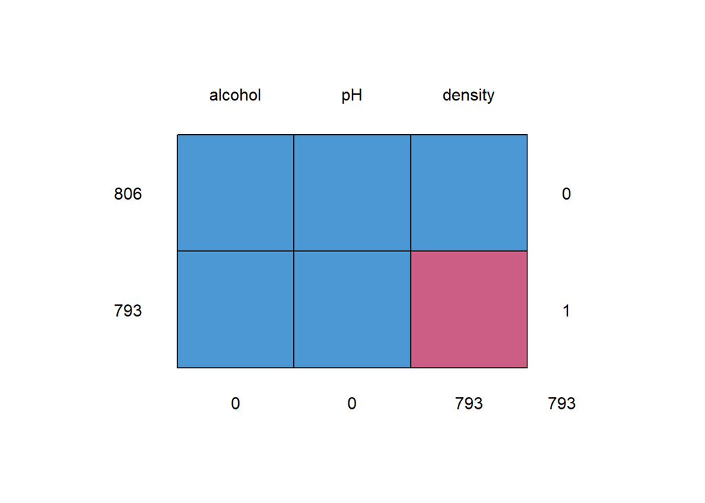

```
##     alcohol pH density
## 806       1  1       1   0
## 793       1  1       0   1
##           0  0     793 793
```

```r
mads <- ampute(data = data,
               patterns = c(1, 0, 1),
               weights = c(0, 0, 1))
inc_data <- mads$amp
md.pattern(inc_data)
```

We are currently in the lucky position of having the original, complete dataset. What did we actually do?

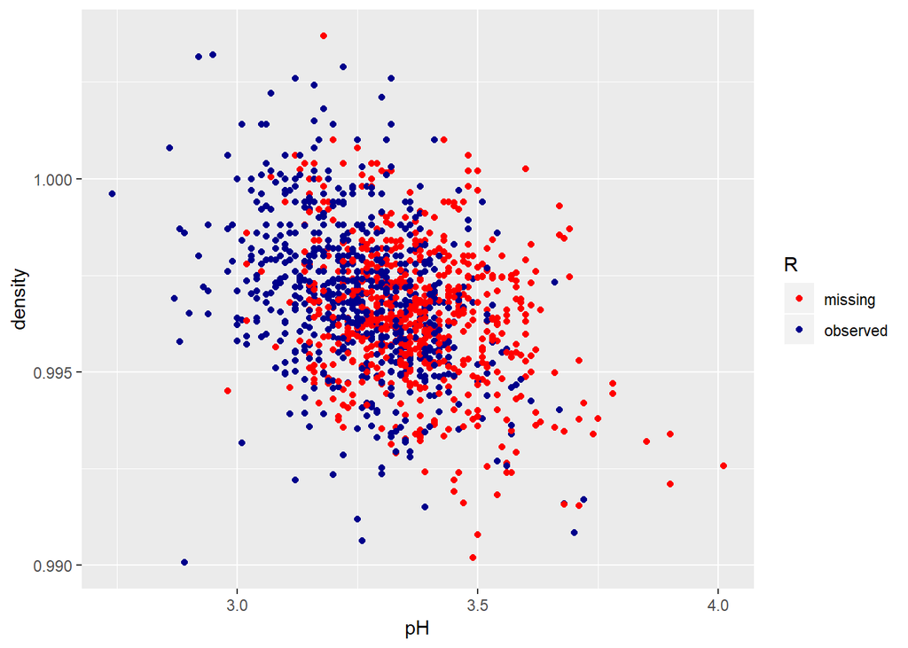

```r
plotdata["R"] <- !is.na(inc_data$density)
ggplot(plotdata, aes(pH, density, color = R)) +
  geom_point() +
  scale_color_manual(values = c('red', 'darkblue'),
                     labels = c('missing', 'observed'))
```

What we see, is that overall the higher values of `pH` have becomes missing. Due to the negative relation between `density` and `pH`, this means the low values of `density` have become incomplete. We can see this effect as well when we model the regression line on the incomplete dataset.

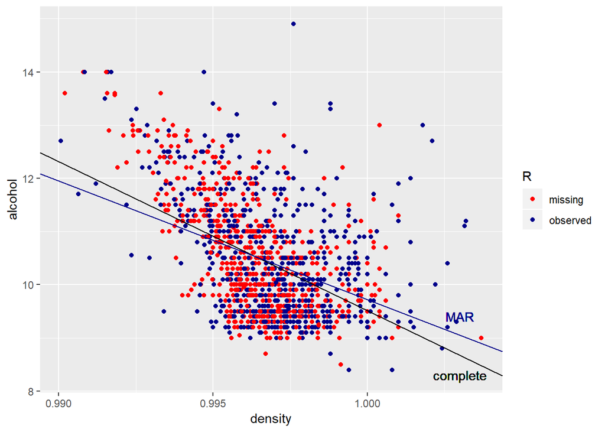

```r
MAR_coefs <- summary(lm(alcohol ~ density,
                        inc_data))$coefficients

ggplot(plotdata, aes(density, alcohol,
                     color = R)) +
  geom_point() +
  geom_text(aes(x = 1.003, y = 8.3),
            label = 'complete', color = 'black') +
  geom_abline(slope = true_coefs[2, 1],
              intercept = true_coefs[1, 1],
              color = 'black') +
  geom_abline(slope = MAR_coefs[2, 1],
              intercept = MAR_coefs[1, 1],
              color = 'darkblue') +
  geom_text(aes(x = 1.003, y = 9.4),
            label = 'MAR', color = 'darkblue') +
  scale_color_manual(values = c('red', 'darkblue'),
                     labels = c('missing', 'observed'))
```

We see that when we delete the incomplete rows from the dataset, the regression line changes.

```r
true_coefs
```

```
##              Estimate Std. Error   t value      Pr(>|t|)
## (Intercept)  289.6753   12.22745  23.69058 1.417989e-106
## density     -280.1638   12.26734 -22.83820 3.938835e-100
```

```r
MAR_coefs
```

```
##              Estimate Std. Error   t value     Pr(>|t|)
## (Intercept)  232.7167   17.44261  13.34185 7.958822e-37
## density     -223.0010   17.49537 -12.74629 5.027353e-34
```

Because of the missingness, bias appears in the estimates. In addition, because we remove all incomplete rows from the dataset, the analyzed dataset becomes smaller and the uncertainty about the estimates becomes larger. Hence, the standard errors increase.

If you want to know more about the influence of missing data mechanisms and missing data types on multivariate normal distributions, read our research article [The dance of the mechanisms: How observed information influences the validity of missingness assumptions](https://journals.sagepub.com/doi/full/10.1177/0049124118799376).

## 3. Missing data methods

When `lm` executes a regression model on a dataset that contains missing values, it will automatically remove the incomplete rows. This approach is called *listwise deletion* or *complete case analysis*. As we have seen, the the method of listwise deletion can greatly disturb the validity of the regression coefficient. In case of MAR and MNAR, bias occurs in the coefficient and the standard error becomes larger.

In the following two exercises, we will try two other missing data methods. The first is a method that is very popular among data scientists: mean imputation.

##### Use the code below to mean impute the incomplete data.

```r
mean_density <- ...
imputations <- rep(...)
imp_data <- inc_data
imp_data[...] <- imputations
```

```r
mean_density <- mean(inc_data$density, na.rm = TRUE)
imputations <- rep(mean_density, nrow(inc_data[is.na(inc_data$density), ]))
imp_data <- inc_data
imp_data[is.na(inc_data$density), 'density'] <- imputations
```

```r
md.pattern(imp_data)
```

```
##  /\     /\
## {  `---'  }
## {  O   O  }
## ==>  V <==  No need for mice. This data set is completely observed.
##  \  \|/  /
##   `-----'
```

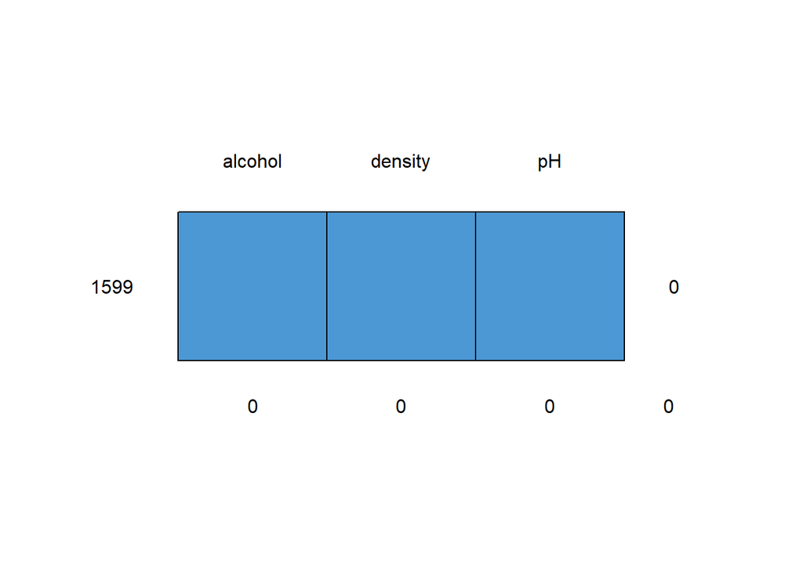

```
##      alcohol density pH
## 1599       1       1  1 0
##            0       0  0 0
```

We see that the dataset indeed has become complete now. But what has happened with our model?

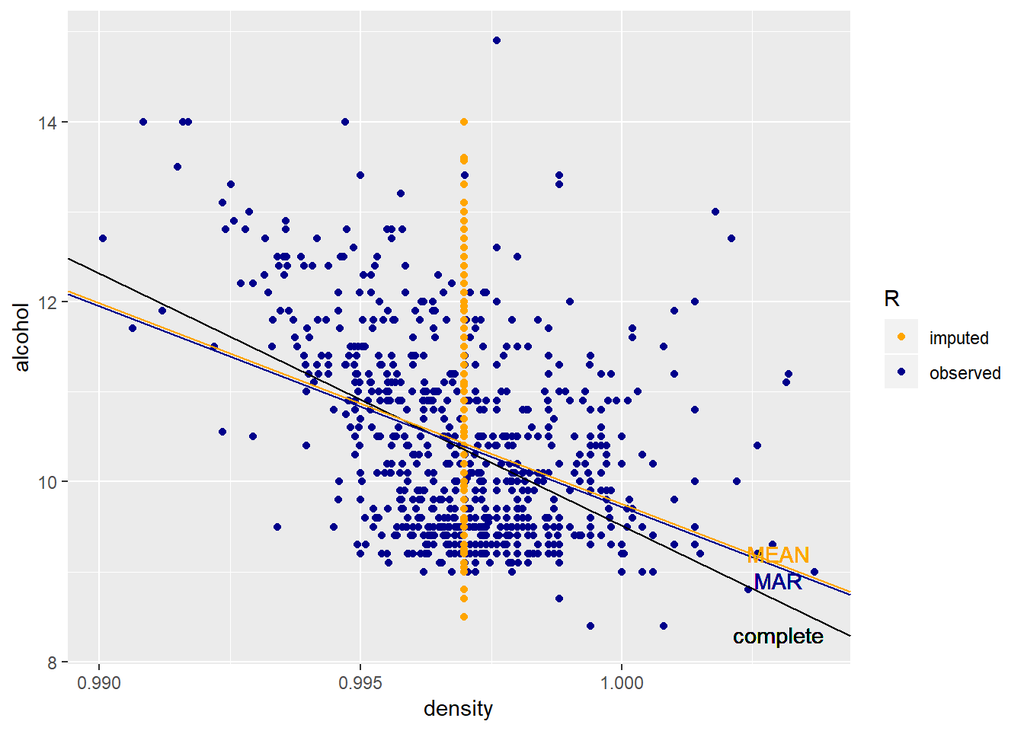

```r
imp_coefs_mean <- summary(lm(alcohol ~ density, imp_data))$coefficients
imp_data["R"] <- !is.na(inc_data$density)

ggplot(imp_data, aes(density, alcohol, color = R)) +
  geom_point() +
  geom_abline(slope = true_coefs[2, 1],
              intercept = true_coefs[1, 1],
              color = 'black') +
  geom_text(aes(x = 1.003, y = 8.3),
            label = 'complete', color = 'black') +
  geom_abline(slope = MAR_coefs[2, 1],
              intercept = MAR_coefs[1, 1],
              color = 'darkblue') +
  geom_text(aes(x = 1.003, y = 8.9),
            label = 'MAR', color = 'darkblue') +
  geom_abline(slope = imp_coefs_mean[2, 1],
              intercept = imp_coefs_mean[1, 1],
              color = 'orange') +
  geom_text(aes(x = 1.003, y = 9.2),
            label = 'MEAN', color = 'orange') +
  scale_color_manual(values = c('orange', 'darkblue'),
                     labels = c('imputed', 'observed'))
```

```r
true_coefs
```

```
##              Estimate Std. Error   t value      Pr(>|t|)
## (Intercept)  289.6753   12.22745  23.69058 1.417989e-106
## density     -280.1638   12.26734 -22.83820 3.938835e-100
```

```r
imp_coefs_mean
```

```
##              Estimate Std. Error   t value     Pr(>|t|)
## (Intercept)  232.7511   18.22571  12.77048 1.243028e-35
## density     -223.0010   18.28085 -12.19861 8.653760e-33
```

The imputed mean stems from the observed data only. Since the observed data is different from the missing data, the imputed mean will not be a good representation of the data. Hence, the bias in the beta coefficient is not gone. Although the dataset is back to 1600 rows, the standard error is still larger than the true standard error. This is because the extra 800 rows do not add extra information.

##### What happens if we use the observed information in `pH`?

```r
imp_model <-
imp_coefs <-
imputations <- inc_data[] * imp_coefs[2, 1] + imp_coefs[1, 1]
imp_data <- inc_data
imp_data[] <- imputations
```

```r
imp_model <- lm(density ~ pH, inc_data)
imp_coefs <- summary(imp_model)$coefficients
imputations <- inc_data[is.na(inc_data$density), 'pH'] * imp_coefs[2, 1] + imp_coefs[1, 1]
imp_data <- inc_data
imp_data[is.na(inc_data$density), 'density'] <- imputations
```

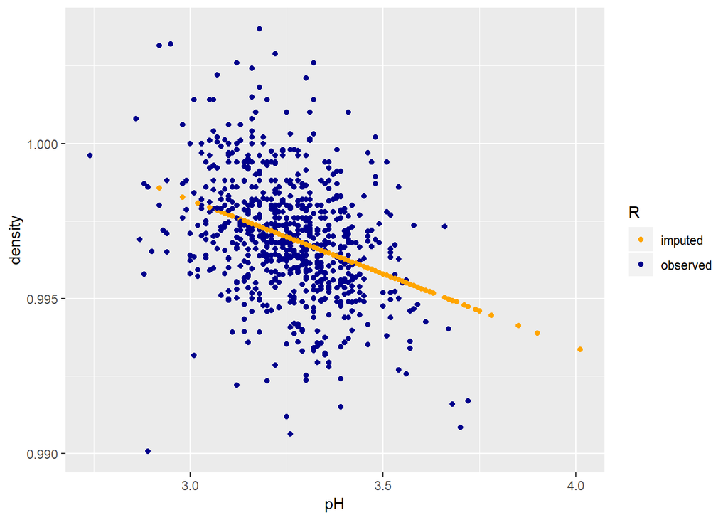

```r
plotdata <- imp_data
plotdata["R"] <- !is.na(inc_data$density)

ggplot(plotdata, aes(pH, density, color = R)) +
  geom_point() +
  scale_color_manual(values = c('orange', 'darkblue'),
                     labels = c('imputed', 'observed'))
```

```r
md.pattern(imp_data)
```

```
##  /\     /\
## {  `---'  }
## {  O   O  }
## ==>  V <==  No need for mice. This data set is completely observed.
##  \  \|/  /
##   `-----'
```

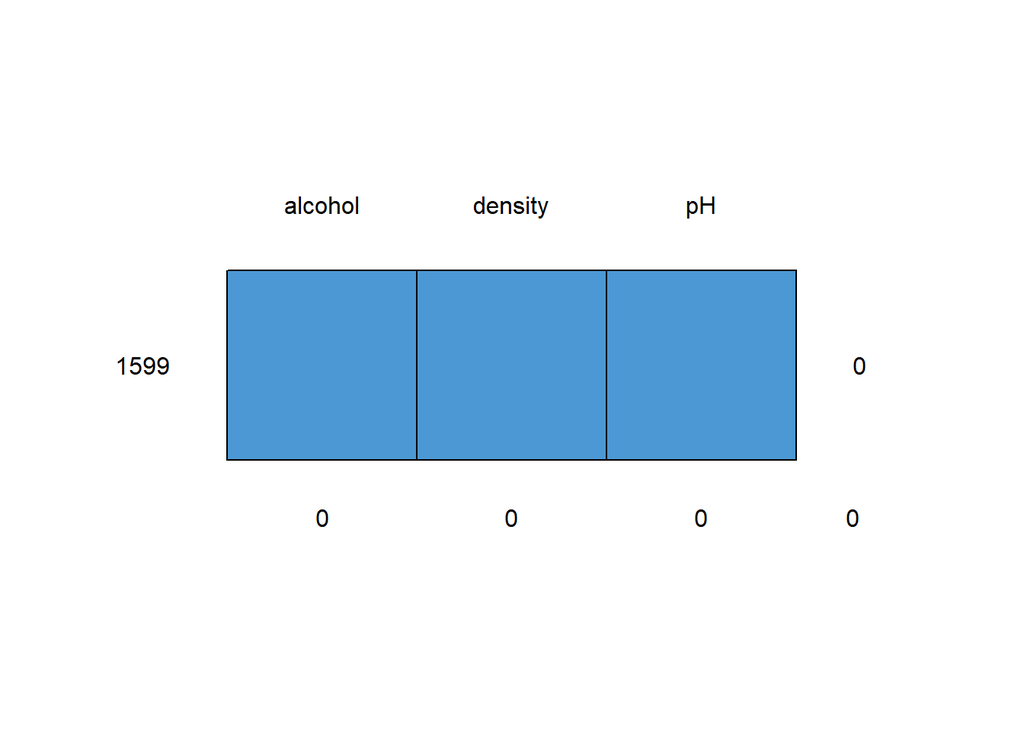

```
##      alcohol density pH
## 1599       1       1  1 0
##            0       0  0 0
```

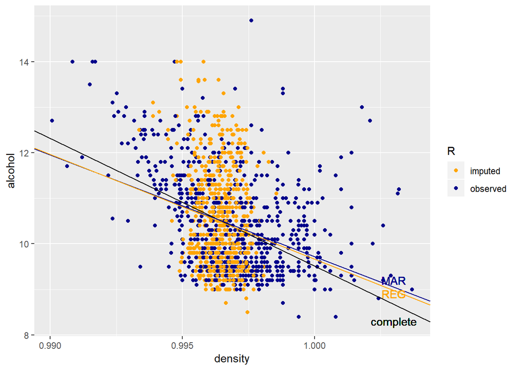

```r
imp_coefs_reg <- summary(lm(alcohol ~ density, imp_data))$coefficients
imp_data["R"] <- !is.na(inc_data$density)

ggplot(imp_data, aes(density, alcohol, color = R)) +
  geom_point() +
  geom_abline(slope = true_coefs[2, 1],
              intercept = true_coefs[1, 1],
              color = 'black') +
  geom_text(aes(x = 1.003, y = 8.3),
            label = 'complete', color = 'black') +
  geom_abline(slope = MAR_coefs[2, 1],
              intercept = MAR_coefs[1, 1],
              color = 'darkblue') +
  geom_text(aes(x = 1.003, y = 9.2),
            label = 'MAR', color = 'darkblue') +
  geom_abline(slope = imp_coefs_reg[2, 1],
              intercept = imp_coefs_reg[1, 1],
              color = 'orange') +
  geom_text(aes(x = 1.003, y = 8.9),
            label = 'REG', color = 'orange') +
  scale_color_manual(values = c('orange', 'darkblue'),
                     labels = c('imputed', 'observed'))
```

The methods we have covered so far are called *single imputation methods*. There is also *multiple imputation*. In fact, package **mice** is developed especially to make multiple imputation fast and easy.

In short, multiple imputation imputes every missing value *m* times. This results in *m* datasets, where the observed data is similar in every dataset, and the imputed data different. The analysis of interest is performed on each of the *m* datasets, and the output is pooled with Rubin’s pooling rules.

Multiple imputation is known to give unbiased results for a wide amount of statistical analyses, as well as an honest standard error. That means, the standard error does justice to the uncertainty in the data due to missing data.

Get to know more about the method of multiple imputation and the functionality of `mice` by reading the brilliant article of stef van Buuren: [mice: Multivariate Imputation by Chained Equations in R](https://www.jstatsoft.org/article/view/v045i03/v45i03.pdf)

## 4. Evaluation

It is not wise to compare an imputed dataset with an amputed dataset only once. The result could be greatly influenced by sampling error. If you want to set up a simulation study, reading [this](https://onlinelibrary.wiley.com/doi/abs/10.1111/1467-9574.00219) article from Jaap Brand might be a good start. He explains two ways to compare the imputed dataset with the complete dataset.

Furthermore, there are other evaluation measures to think of when you compare the imputed dataset with the truth. A data scientist, for instance, might be more interested in the prediction error. The difference between evaluating bias and standard errors on the one hand, and evaluation prediction error measures on the other hand, is still unclear. More research on that has to be done.

## Summary

Beforehand, I specified 3 takeaways.

1. Missing data happens with different underlying mechanisms

MCAR, MAR and MNAR.

2. Simple R-functions like ‘md.pattern’ and ‘ampute’ help to investigate the missingness

Missingness could occur in different variables. With `ampute`, you can simulate these patterns. With `md.pattern`, you can inspect the patterns and understand more about the relation between the complete and incomplete data.

3. The appropriateness of a missing data method depends on the missing data problem

The larger the impact of the missing data on the analysis, the stronger the imputation method should be. Listwise deletion is not a strong method, and mean imputation only works when the mean value is the statistic of interest and the mechanism is MCAR missingness.

For regression analysis with MAR missingness, regression imputation might be sufficient. To be sure the standard error is account for properly, multiple imputation is the best way to go.

## Contact details

Do not hestitate to ask questions by email. My contact details are on https://rianneschouten.github.io/ Also, follow me on twitter:

[figure not shown]